# Real-world size is automatically encoded in preschoolers’ object representations: Open-source analyses

Bria Long

2/7/2018, updated fall 2018

# Experiment 1

## Preprocessing

### Load files and compute descriptives

```r
## Compiled data files for all children tested
e1_fileName="data/Experiment1_All.csv" #

## Demographics sheet for E1
demographics <- read.csv("demographics/Experiment1_SubjectsbyAge.csv") %>%
  mutate(Subject = as.factor(Subject))
# avg and std of age
ageOut <- demographics %>%
  distinct(FileName, Age, AgeGroup) %>%
  group_by(AgeGroup) %>%
  summarize(meanAge=mean(Age), sdAge=sd(Age), numKids=length(Age))

# for all subjects, count # of slow trials that were correct
slowPercent <- read.csv(e1_fileName) %>%
  mutate(Subject = factor(id))  %>%
  filter(trial>10, correct ==1)  %>%
  group_by(Subject) %>%
  summarize(countTrials = length(RT), slowTrials = sum(RT>4000)) %>%
  group_by(Subject) %>%
  summarize(percentSlowTrials = slowTrials / countTrials)
```

### Compute set of included subjects and their basic descriptives

```r
# Subjects who have 5 or more trials after practice
includedSubs_PC <- read.csv(e1_fileName) %>%
  mutate(Subject = factor(id), Congruency = factor(condition))  %>%
  left_join(demographics) %>% # join ages
  filter(trial>10)  %>% # eliminate practice trials
  group_by(FileName, Subject, Congruency, AgeGroup, Age)  %>%
  summarize(countTrials = length(RT))  %>% # how many trails per condition
  filter(countTrials>4) %>% # exclude if less than five speeded correct per cond
  group_by(FileName, Subject, AgeGroup, Age)  %>%
  mutate(countTrialsOK = length(countTrials)) %>%
  filter(countTrialsOK==2) %>% # 5 or more trials in each condition
  group_by(FileName, Subject, AgeGroup, Age,countTrials)
# Compile list of included subjects who had 5 or more speeded correct trials in each condition
includedSubs_RT <- read.csv(e1_fileName) %>%
  mutate(Subject = factor(id), Congruency = factor(condition))  %>%
  left_join(demographics) %>% # join ages
  filter(RT<4000, correct == 1, trial>10)  %>% # speeded, correct trials after practice
  group_by(FileName, Subject, Congruency, AgeGroup, Age)  %>%
  summarize(countTrials = length(RT))  %>% # how many trails per condition
  filter(countTrials>4) %>% # exclude if less than five speeded correct per cond
  group_by(FileName, Subject, AgeGroup, Age)  %>%
  mutate(countTrialsOK = length(countTrials)) %>%
  filter(countTrialsOK==2) %>% # 5 or more trials in each condition
  group_by(FileName, Subject, AgeGroup, Age,countTrials)
## which subjects were excluded?
excludedSubs_RT <- demographics %>%
  filter(!is.element(FileName,includedSubs_RT$FileName))

excludedSubs_PC <- demographics %>%
  filter(!is.element(FileName,includedSubs_PC$FileName))

#  report out summary for the RT demographics
trialSummary_RT <- includedSubs_RT %>%
  group_by(Subject) %>%
  mutate(countTrialsTotal = sum(countTrials)) %>% # count total trials for reporting
  distinct(Subject, countTrialsTotal, AgeGroup, Age) %>%
  group_by(AgeGroup) %>%
  summarize(uniqueSubjects = length(unique(Subject)), countTrialsAvg = mean(countTrialsTotal), countTrialsSD=sd(countTrialsTotal), AgeMean=mean(Age), AgeSD=sd(Age))

# report out summary for the PC demographics
trialSummary_PC <- includedSubs_PC %>%
  group_by(Subject) %>%
  mutate(countTrialsTotal = sum(countTrials)) %>% # count total trials for reporting
  distinct(Subject, countTrialsTotal, AgeGroup, Age) %>%
  group_by(AgeGroup) %>%
  summarize(uniqueSubjects = length(unique(Subject)), countTrialsAvg = mean(countTrialsTotal), countTrialsSD=sd(countTrialsTotal), AgeMean=mean(Age), AgeSD=sd(Age))
```

### Subjects descriptive paragraph for E1

One child began the task but did not complete more than two trials. This left us with 79 children in the final sample, with 48 3-year-olds (M = 41.83 months, SD = 2.97 months) and 31 4-year-olds (M = 53.65 months, SD = 3.4 months).

We assessed both accuracy and reaction time dependent measures, both as a single group of participants, and separately for 3 and 4 year-old groups, within trials in which children were on-task. To do so, we adopted the following exclusion criteria and data-trimming methods. First, we excluded all geometric shape trials and, a priori, the first 10 trials from the test phase. Three children (all 3-year-olds) did not complete more than five trials in each condition after these first 10 trials, and were excluded from all subsequent analyses. Error analyses were thus conducted on 76 children. Error analyses were thus conducted on the remaining 76 children, with 3-year-olds who on average contributed 54.47trials and 4-year-olds who on average contributed 52.06 trials to error analyses.

For reaction time analyses, we additionally excluded incorrect trials and trials with RTs slower than 4 seconds (6.55 of correct trials). This RT cutoff has previously been used as a cutoff when analyzing preschooler’s reaction times in a touchscreen-based task (Frank et al., 2016), in order to eliminate extra-long trials where children are likely off-task. Children were included if, after this RT trimming procedure, they had at least 5 correct trials per condition (congruent, incongruent). Four additional children were excluded for not meeting these criteria, all 3-year-olds. This left us with 72 children for RT analyses: 41 three-year-olds (M = 42.17 months, SD = 2.93 months) and all of the 31 four-year-olds. On avearge, 3-year-olds contributed 47.41 correct, speeded trials to RT analyses, and 4-year-olds contributed 47.77 correct, speeded trials to RT analyses.

## Error analyses

### Load data

```r
### ERRORS ###  read in the data

# list of subjects included
demoUnique_PC <- includedSubs_PC %>%
  group_by(Subject) %>%
  select(-c(Congruency, countTrials))  %>%
  distinct(Subject,AgeGroup)

# to look at errors after practice trials
ErrorData_E1<- read.csv(e1_fileName) %>%
  mutate(Subject=factor(id)) %>%
  select(-(id)) %>%
  left_join(demographics) %>% # joins exact age information to datafile
  inner_join(demoUnique_PC) %>%
  mutate(error = 1-correct) %>%
  filter(trial > 10) %>% # get rid of practice trials
  mutate(Item = factor(imagePair), Subject=factor(Subject), Congruency = factor(condition), AgeGroup = factor(AgeGroup), FamVersion = factor(FamVersion))
## for use in posthoc error analyses
ErrorData_E1_AllTrials<- read.csv(e1_fileName) %>%
  mutate(Subject=factor(id)) %>%
  select(-(id)) %>%
  left_join(demographics) %>% # joins exact age information to datafile
  inner_join(demoUnique_PC) %>%
  mutate(error = 1-correct) %>%
  mutate(Item = factor(imagePair), Subject=factor(Subject), Congruency = factor(condition), AgeGroup = factor(AgeGroup), FamVersion = factor(FamVersion))
# to only look at errors during practice trials
ErrorData_E1_Practice<- read.csv(e1_fileName) %>%
  mutate(Subject=factor(id)) %>%
  select(-(id)) %>%
  left_join(demographics) %>%
  inner_join(demoUnique_PC) %>%
  mutate(error = 1-correct) %>%
  filter(trial <= 10) %>% # only look at practice trials
  mutate(Item = factor(imagePair), Subject=factor(Subject), Congruency = factor(condition), AgeGroup = factor(AgeGroup), FamVersion = factor(FamVersion))
```

### Compute descriptives by age, condition, and their combination

```r
### Error descriptives for paragraph below
ErrorData_E1_Summary<- ErrorData_E1 %>%
  group_by(Subject) %>%
  summarize(meanSubError = mean(error)) %>%
  summarize(meanError = mean(meanSubError)*100)

ErrorData_E1_SummarybyAge<- ErrorData_E1 %>%
  group_by(Subject,AgeGroup) %>%
  summarize(meanSubError = mean(error)) %>%
  group_by(AgeGroup)  %>%
  summarize(meanError = mean(meanSubError)*100)

ErrorData_E1_SummarybyCond<- ErrorData_E1 %>%
  group_by(Subject,Congruency) %>%
  summarize(meanSubError = mean(error)) %>%
  group_by(Congruency)  %>%
  summarize(meanError = mean(meanSubError)*100, stdError = sd(meanSubError)*100)

ErrorData_E1_SummarybyCondbyAge<- ErrorData_E1 %>%
  group_by(Subject,Congruency,AgeGroup) %>%
  summarize(meanSubError = mean(error)) %>%
  group_by(AgeGroup,Congruency)  %>%
  summarize(meanError = mean(meanSubError)*100, stdError = sd(meanSubError)*100)
```

### Check familiarization version didn’t make a difference

```r
## Basic ANOVA
aov.errors.famversion = ezANOVA(data = ErrorData_E1, dv=.(error), wid=.(Subject), within=.(Congruency), between=.(FamVersion), type=3)
print(aov.errors.famversion)
```

```
## $ANOVA
##                  Effect DFn DFd          F           p p<.05         ges
## 2            FamVersion   1  74  3.3548628 0.071031307       0.036505480
## 3            Congruency   1  74 12.1207144 0.000840292     * 0.026201433
## 4 FamVersion:Congruency   1  74  0.6204438 0.433398243       0.001375411
```

```r
## Descriptive stats by familarization condition
ErrorData_E1_byFamCondition<- ErrorData_E1 %>%
  group_by(Subject,Congruency,FamVersion) %>%
  summarize(meanSubError = mean(error)) %>%
  group_by(FamVersion)  %>%
  summarize(meanError = mean(meanSubError)*100, stdError = sd(meanSubError)*100)
```

Children in these two familiarization versions did not perform more or less accurately on test trials (no main effect of familiarization version on error rates; F(1,74) = 3.35, p = 0.07) and or on congruent versus incongruent displays (no interaction of familiarization version with trial type on error rates; F(1,74) = 0.62, p= 0.43).

### How many errors did children make during practice trials?

```r
ErrorData_E1_Practice_Summary <- ErrorData_E1_Practice %>%
  group_by(Subject,AgeGroup) %>%
  summarize(meanSubError = mean(error)) %>%
  group_by(AgeGroup) %>%
  summarize(meanError = mean(meanSubError), sdError = sd(meanSubError))
```

(Foonote 5): This cutoff of 10 trials was chosen after piloting the task in a separate group of children and noticing that some children were still responding very slowly during the first few trials. However, error rates were still relatively low during these first 10 practice trials (3-year-olds, average M=11.6%, SD = 15.2%; 4-year-olds, average M=3.9%, SD = 7.2)%

### Main inferential statistics on error rates

```r
## Basic ANOVA
aov.errors = ezANOVA(data = ErrorData_E1, dv=.(error), wid=.(Subject), within=.(Congruency), between=.(AgeGroup), type=3)
print(aov.errors)
```

```
## $ANOVA
##                Effect DFn DFd          F            p p<.05          ges
## 2            AgeGroup   1  74  7.0775035 0.0095657575     * 0.0734284382
## 3          Congruency   1  74 11.8652746 0.0009453361     * 0.0267497649
## 4 AgeGroup:Congruency   1  74  0.3107761 0.5788868211       0.0007193706
```

```r
#Random slopes and intercepts were perfectly anticorrelated for items
Errors_glmer_E1 = glmer(error ~ Congruency + (1 | Subject) + (1|Item), data=ErrorData_E1, family="binomial")
Errors_glmer_E1_out=data.frame(round(summary(Errors_glmer_E1)$coef,3))
kable(Errors_glmer_E1_out)
```

|  | Estimate | Std..Error | z.value | Pr…z.. |
| --- | --- | --- | --- | --- |
| (Intercept) | -3.202 | 0.204 | -15.674 | 0 |
| Congruency2 | 0.566 | 0.116 | 4.896 | 0 |

### Post-hoc tests by age group on error rates

```r
## Break out by age group for t-tests
ErrorData_E1_CondbyAge<- ErrorData_E1 %>%
  group_by(Subject,Congruency,AgeGroup) %>%
  summarize(meanSubError = mean(error)) %>%
  group_by(Congruency,AgeGroup)

# 3 year olds
cong_3years=ErrorData_E1_CondbyAge$meanSubError[ErrorData_E1_CondbyAge$Congruency==1 & ErrorData_E1_CondbyAge$AgeGroup==1]
incong_3years=ErrorData_E1_CondbyAge$meanSubError[ErrorData_E1_CondbyAge$Congruency==2 & ErrorData_E1_CondbyAge$AgeGroup==1]
# 4 year olds
cong_4years=ErrorData_E1_CondbyAge$meanSubError[ErrorData_E1_CondbyAge$Congruency==1 & ErrorData_E1_CondbyAge$AgeGroup==2]
incong_4years=ErrorData_E1_CondbyAge$meanSubError[ErrorData_E1_CondbyAge$Congruency==2 & ErrorData_E1_CondbyAge$AgeGroup==2]

error_3YearOlds=t.test(incong_3years,cong_3years,alternative = "greater", paired=TRUE, var.equal = TRUE)
error_4YearOlds=t.test(incong_4years,cong_4years,alternative = "greater", paired=TRUE, var.equal = TRUE)

# check if these results also hold when 2-sample t-test (for R1)
error_3YearOlds_2samp=t.test(incong_3years,cong_3years, paired=TRUE, var.equal = TRUE)
error_4YearOlds_2samp=t.test(incong_4years,cong_4years, paired=TRUE, var.equal = TRUE)

# compute avg and sd of error difference
avg_stroop_error_3yr=mean(incong_3years-cong_3years)
sd_stroop_error_3yr=sd(incong_3years-cong_3years)

avg_stroop_error_4yr=mean(incong_4years-cong_4years)
sd_stroop_error_4yr=sd(incong_4years-cong_4years)
```

### Error results paragraph (E1)

Children made relatively few errors (M = 10.61%) suggesting they understood the task instructions, though 3-year-olds made more errors than 4-year-olds (main effect of age: 3-year-olds: M = 14.06%, 4-year-olds: M = 5.6%, F(1,74) = 7.08, p = 0.01, ηG2 = 0.07). In addition, children showed evidence for the Size-Stroop effect in their errors; they made more errors on incongruent than congruent displays (main effect of trial type: congruent M = 8.03 (SD = 12.13%), incongruent M = 13.19 (SD = 18.33%), F(1,74) = 11.87, p = 0, ηG2 = 0.03). The Size-Stroop effect was apparent throughout this age range; there was no interaction between age group and trial type (F(1,74) = 0.31, p = 0.58, ηG2 < 0).

Finally, planned ad-hoc comparisons confirmed that the Size-Stroop effect was observed at each age: 3-year-olds: congruent M = 11.17%, incongruent M = 17%, t(44) = 2.88, p = 0.003.

4-year olds: congruent M = 3.47%, incongruent M = 7.67%, t(30) = 2.2, p = 0.018 see Figure 3A. Our GLMM model confirmed these analyses, finding that this effect generalized across individual subjects and items (B = 0.566, SE = 0.116, Z = 4.896, p < .001).

….Indeed the relative difference in error rates across conditions was relatively similar between 3-year-olds and 4-year-olds (3-year-olds, Mincong – cong = 5.8%, SD = 13.6%; 4-year-olds, Mincong – cong = 4.2%, SD = 10.7%, see all individual data in Supplemental Figures 2 and 3).

### Do error rates differ across the experiment? Seems relatively consistent

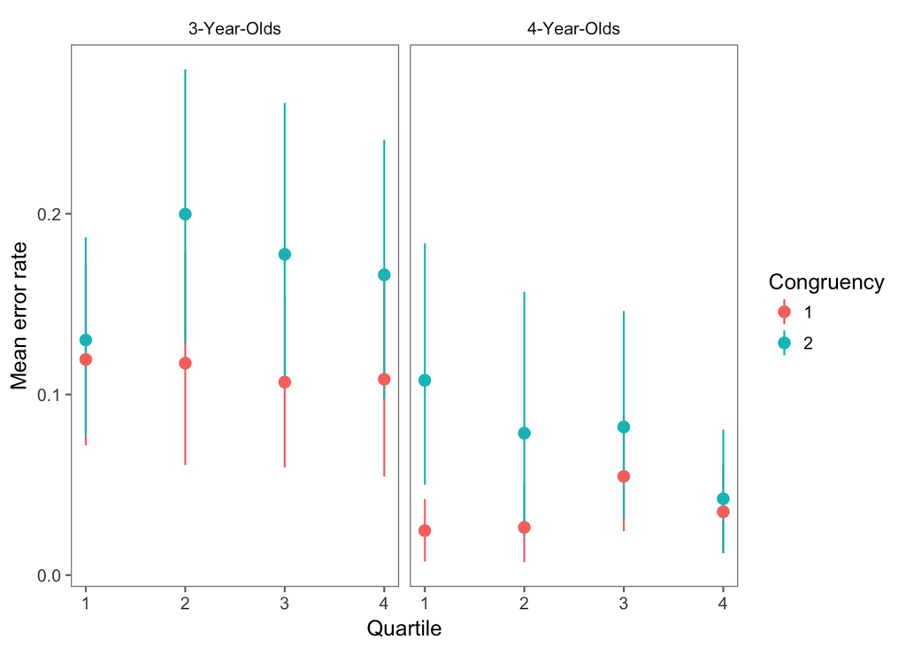

```r
## Main analyses - error rates across quartiles after practice trials
ErrorRatesbyQuartiles<- ErrorData_E1 %>%
  group_by(Subject,AgeGroup) %>%
  mutate(quartile = ntile(trial, 4)) %>% ## create quartiles for each subject by trial
  group_by(Subject,quartile,AgeGroup)  %>%
  summarize(meanSubError = mean(error)) %>%
  group_by(AgeGroup,quartile) %>%
  summarize(meanError = mean(meanSubError))

## Break down by congruency
ErrorRatesbyQuartilesbyCond<- ErrorData_E1 %>%
  group_by(Subject,AgeGroup) %>%
  mutate(quartile = ntile(trial, 4)) %>% ## create quartiles for each subject by trial
  group_by(Subject,quartile,AgeGroup, Congruency)  %>%
  summarize(meanSubError = mean(error)) %>%
  group_by(quartile,AgeGroup, Congruency)  %>%
  multi_boot_standard(col = "meanSubError")

## Make a descriptive plot
levels(ErrorRatesbyQuartilesbyCond$AgeGroup) <- c("3-Year-Olds","4-Year-Olds")
ggplot(data = ErrorRatesbyQuartilesbyCond, aes(quartile, mean)) +
  theme_few() +
  geom_pointrange(aes(ymin=ci_lower, ymax = ci_upper, color=Congruency)) +
  facet_grid(~AgeGroup) +
  labs(y = "Mean error rate", x = "Quartile")
```

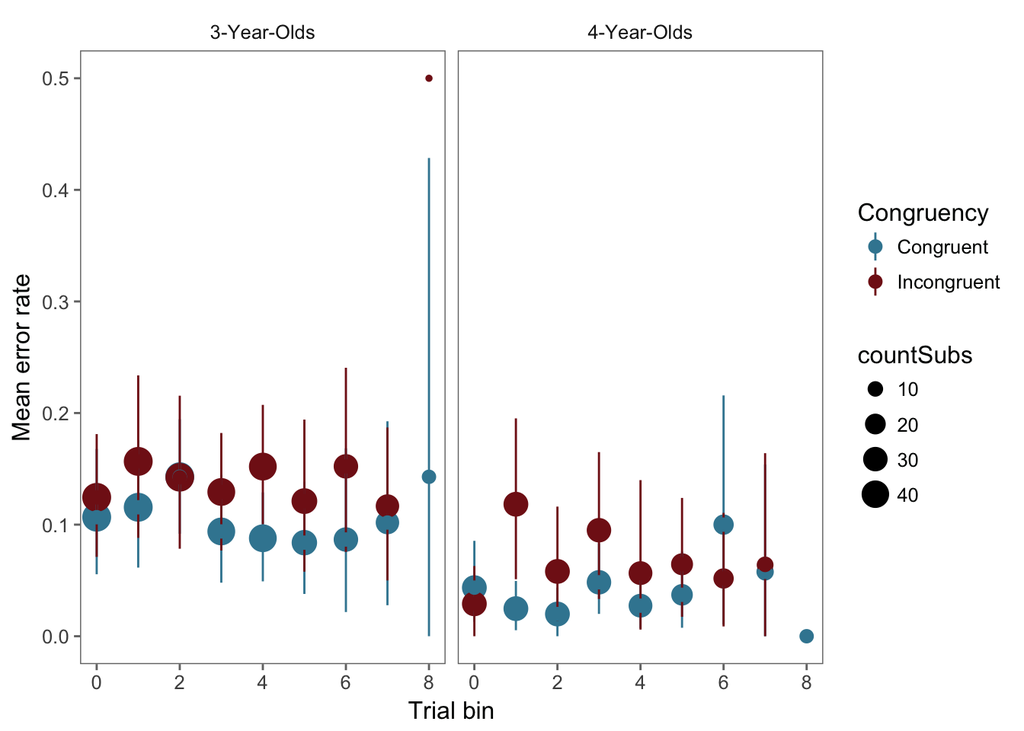

```r
## Extra analyses -  do this by trial bin as well
ErrorRatesbyTrialBin<- ErrorData_E1_AllTrials %>%
  group_by(Subject,AgeGroup) %>%
  mutate(trial_bin = floor(trial/10)) %>%
  group_by(Subject,trial_bin,AgeGroup, Congruency)  %>%
  summarize(meanSubError = mean(error))

countSubs <- ErrorRatesbyTrialBin %>%
  group_by(AgeGroup,trial_bin,Congruency) %>%
  summarize(countSubs = n())

ErrorRatesbyTrialBin_toPlot <- ErrorRatesbyTrialBin %>%
  group_by(AgeGroup,trial_bin,Congruency) %>%
  multi_boot_standard(col = "meanSubError") %>%
  left_join(countSubs)
## Plot it
levels(ErrorRatesbyTrialBin_toPlot$AgeGroup) <- c("3-Year-Olds","4-Year-Olds")
levels(ErrorRatesbyTrialBin_toPlot$Congruency) <- c("Congruent","Incongruent")
ggplot(data = ErrorRatesbyTrialBin_toPlot, aes(trial_bin, mean)) +
  theme_few() +
  geom_point(aes(size=countSubs, color=Congruency)) +
  geom_pointrange(aes(ymin=ci_lower, ymax = ci_upper, color=Congruency)) +
  scale_color_manual(values = c("#3C86A0", "#821919"))+
  facet_grid(~AgeGroup) +
  labs(y = "Mean error rate", x = "Trial bin") +
  ylim(c(0,.5))
```

We also found that children’s overall error rates were consistent in both age groups across the session, suggesting that they did not initially know the instructions and then forget them over time (3-year-olds, M=12.7%, M=15.8%,M=14.4%,M=13.6%; 4-year-olds,M=6.3%, M=5.4%,M=6.8%,M=3.8%).

## Reaction time analyses

### Read in data

```r
# Get list of the subjects that passed inclusion threshold
demoUnique_RT <- includedSubs_RT %>%
  group_by(Subject) %>%
  select(-c(Congruency, countTrials))  %>%
  distinct(Subject,AgeGroup)

RTData_E1 <- read.csv(e1_fileName) %>%
  mutate(Subject =factor(id)) %>%
  select(-(id)) %>%
  inner_join(demoUnique_RT) %>%
  left_join(demographics) %>%
  filter(RT<4000, correct == 1, trial>10) %>%
  mutate(logRT = log(RT)) %>%
  mutate(Item = factor(imagePair), Congruency = factor(condition), AgeGroup = factor(AgeGroup))
RTbyCond_All <- RTData_E1 %>%
  group_by(Congruency) %>%
  summarize(meanRT = mean(RT), stdRT=sd(RT))
```

### Inferential statistics on reaction times

```r
# run age x congruency anova
aov.rt = ezANOVA(data = RTData_E1, dv=.(RT), wid=.(Subject), within=.(Congruency), between=.(AgeGroup), type=3)
print(aov.rt)
```

```
## $ANOVA
##                Effect DFn DFd         F           p p<.05          ges
## 2            AgeGroup   1  70 11.513489 0.001140562     * 0.1335432847
## 3          Congruency   1  70  0.902733 0.345318918       0.0008110594
## 4 AgeGroup:Congruency   1  70  3.124028 0.081504070       0.0028011889
```

```r
# Linear mixed effect models -- confirm with LME4 on logRT
RT_lmer_E1_full = lmer(logRT ~ Congruency*AgeGroup + (1+ Congruency | Subject) + (1 + Congruency|Item), data=RTData_E1)
# Output table
kable(summary(RT_lmer_E1_full)$coef)
```

|  | Estimate | Std. Error | df | t value | Pr(>\|t\|) |
| --- | --- | --- | --- | --- | --- |
| (Intercept) | 7.4814062 | 0.0385559 | 71.67492 | 194.0404628 | 0.0000000 |
| Congruency2 | 0.0023510 | 0.0202535 | 40.96408 | 0.1160772 | 0.9081585 |
| AgeGroup2 | -0.1997608 | 0.0582000 | 69.71730 | -3.4323169 | 0.0010105 |
| Congruency2:AgeGroup2 | 0.0456426 | 0.0251490 | 65.34548 | 1.8148834 | 0.0741316 |

```r
lmerFullOut=data.frame(round(summary(RT_lmer_E1_full)$coef,3))
```

Reaction Time Results. When we considered both 3- and 4-year-olds together, we found that, overall, children did not take longer to make visual size judgments on incongruent versus congruent displays (no main effect of trial type: congruent M= 1758, incongruent M = 1778, F(1,70) =0.9, p = 0.35, ηG2 = 0).

### Post-hoc RT analyses by age group

```r
## Average by subject first
RTbyCond_3 <- RTData_E1 %>%
  filter(AgeGroup==1) %>%
  group_by(Subject, Congruency) %>%
  summarize (meanSubRT = mean(RT))

RTbyCond_4 <- RTData_E1 %>%
  filter(AgeGroup==2) %>%
  group_by(Subject, Congruency) %>%
  summarize (meanSubRT = mean(RT))

## Then by condition for descriptives
RTbyCond_4_Avg <- RTbyCond_4 %>%
  group_by(Congruency) %>% ## already grouped by subject here
  summarize (meanRT = mean(meanSubRT), sdRT = sd(meanSubRT))

RTbyCond_3_Avg <- RTbyCond_3 %>%
  group_by(Congruency) %>% ## already grouped by subject here
  summarize (meanRT = mean(meanSubRT), sdRT = sd(meanSubRT))
```

```r
## Post-hoc t-tests
# 3-year-olds
stroopRT_3Years=t.test(RTbyCond_3$meanSubRT[RTbyCond_3$Congruency==2], RTbyCond_3$meanSubRT[RTbyCond_3$Congruency==1], alternative = "greater", paired=TRUE, var.equal = TRUE)

# 4-year-olds
stroopRT_4Years=t.test(RTbyCond_4$meanSubRT[RTbyCond_4$Congruency==2], RTbyCond_4$meanSubRT[RTbyCond_4$Congruency==1], alternative = "greater", paired=TRUE, var.equal = TRUE)

## 2-sample t-tests
# 3-year-olds
stroopRT_3Years_2samp=t.test(RTbyCond_3$meanSubRT[RTbyCond_3$Congruency==2], RTbyCond_3$meanSubRT[RTbyCond_3$Congruency==1], paired=TRUE, var.equal = TRUE)

# 4-year-olds
stroopRT_4Years_2samp=t.test(RTbyCond_4$meanSubRT[RTbyCond_4$Congruency==2], RTbyCond_4$meanSubRT[RTbyCond_4$Congruency==1], paired=TRUE, var.equal = TRUE)

stroopRT_4Years_cohensD <- RTbyCond_4 %>%
  group_by(Subject) %>%
  summarize(effectBySub = meanSubRT[Congruency==2] - meanSubRT[Congruency==1] ) %>%
  summarize(meanDiff = mean(effectBySub), stdDiff=sd(effectBySub)) %>%
  mutate(cohensD = meanDiff/stdDiff)

stroopRT_3Years_cohensD <- RTbyCond_3 %>%
  group_by(Subject) %>%
  summarize(effectBySub = meanSubRT[Congruency==2] - meanSubRT[Congruency==1] ) %>%
  summarize(meanDiff = mean(effectBySub), stdDiff=sd(effectBySub)) %>%
  mutate(cohensD = meanDiff/stdDiff)

### Mixed effect models on RT for 4-year-olds
RTbyCond_4_Raw <- RTData_E1 %>%
  filter(AgeGroup==2)

RT_lmer_E1_4YearOlds = lmer(logRT ~ Congruency + (1 + Congruency| Subject) + (1 + Congruency|Item), data=RTbyCond_4_Raw)

kable(summary(RT_lmer_E1_4YearOlds)$coef)
```

|  | Estimate | Std. Error | df | t value | Pr(>\|t\|) |
| --- | --- | --- | --- | --- | --- |
| (Intercept) | 7.2812199 | 0.0393569 | 30.98461 | 185.004813 | 0.0000000 |
| Congruency2 | 0.0470507 | 0.0212814 | 21.32407 | 2.210884 | 0.0380953 |

```r
lmerOut=summary(RT_lmer_E1_4YearOlds)$coef
lmer4YrsOut=data.frame(round(summary(RT_lmer_E1_4YearOlds)$coef,3))
```

### Reaction time results paragraph (E1)

However, we planned to examine results for 3- and 4-year-olds separately, as we anticipated that 3-year-olds might not be able to perform the task as well as 4-year-olds. These planned ad-hoc tests revealed that 4-year-olds showed the Size-Stroop effect in their RTs (congruent M = 1555, SD = 359, incongruent M = 1622, SD = 319, t(30) = 2.37, p = 0.01, Cohen’s d = 0.43), while the 3-year-olds did not (congruent M = 1921, SD = 475, incongruent M = 1901, SD = 446, t(40) = -0.54, p = 0.705, Cohen’s d = -0.08, Figure 3B).

### What predicts whether a child will show the Size-Stroop effect?

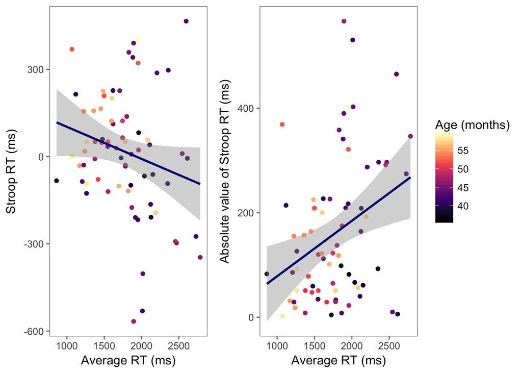

```r
overallRT <- RTData_E1 %>%
  group_by(Subject) %>%
  summarize (meanRT = mean(RT), sdRT = sd(RT), age=Age[1])

StroopbySub <- RTData_E1 %>%
  group_by(Subject, Congruency) %>%
  summarize (meanRT = mean(RT)) %>%
  left_join(demographics) %>%
  group_by(Subject) %>%
  summarize(StroopRT = meanRT[Congruency==2] - meanRT[Congruency==1], Age=Age[1]) %>%
  mutate(AbsStroopRT = abs(StroopRT)) %>%
  left_join(overallRT) ## join overall RT data
StroopErrorbySub <- ErrorData_E1 %>%
  group_by(Subject, Congruency) %>%
  summarize (meanError = mean(error)) %>%
  left_join(demographics) %>%
  group_by(Subject) %>%
  summarize(StroopError = meanError[Congruency==2] - meanError[Congruency==1], Age=Age[1])
# Age vs. Stroop RT
AgevStroop=cor.test(StroopbySub$Age, StroopbySub$StroopRT)

# Age vs. AbsStroop ER
AgevAbsStroop=cor.test(StroopbySub$Age, StroopbySub$AbsStroopRT)

# Age vs. Stroop Error
AgevStroopError=cor.test(StroopErrorbySub$Age, StroopErrorbySub$StroopError)

# Mean RT vs. Age
# RTvAge=cor.test(overallRT$meanRT, StroopbySub$Age)

# Mean RT vs. Stroop
RTvStroop=cor.test(overallRT$meanRT, StroopbySub$StroopRT)

# Mean RT vs. Abs(StroopRT)
RTvAbsStroop=cor.test(overallRT$meanRT, StroopbySub$AbsStroopRT)

## use cocor package to compare correlations
StroopbySub_DF=as.data.frame(StroopbySub) # convert to dataframe for package functions.
out = cocor(~StroopRT + meanRT | AbsStroopRT + meanRT, StroopbySub_DF)
## Report williams' t (1959) though all tests are significant.

toPlot <- StroopbySub %>%
  left_join(overallRT)
base_size_sup3 = 12 # for rendering in-line
# base_size_sup3 = 18  # for making figure

# make plots to visualize these
g1=ggplot(toPlot, aes(x = meanRT, y = StroopRT, col=age)) +
  geom_point()  +
  geom_smooth(method="lm", color="navy") +
  theme_few(base_size = base_size_sup3) +
  scale_color_viridis(option="A") +
  theme(legend.position = "none") +
  labs(x = "Average RT (ms)", y ="Stroop RT (ms)")

g2=ggplot(toPlot, aes(x = meanRT, y = AbsStroopRT, col=age)) +
  geom_point()  +
  geom_smooth(method="lm", color="navy") +
  theme_few(base_size = base_size_sup3) +
  scale_color_viridis(option="A", name ="Age (months)") +
  labs(x = "Average RT (ms)", y ="Absolute value of Stroop RT (ms)")

SuppFigure2=ggarrange(g1,g2, nrow=1)
```

```r
ggsave("SuppFigure3-Correlations.tiff", width = 11.5, height = 5,unit =  "in", plot = SuppFigure2, path="./figures/", device = "tiff",dpi = 300)
```

### Exploratory correlations paragraph

Footnote: Age was not positively correlated with absolute valued Stroop RT effects, r = -0.04, p = 0.72).

# Experiment 2: Replication in fast four-year-olds

## Load in data, counting of trials for demographics

```r
e2_fileName="data/Experiment2_All.csv" #
demographics_e2 <- read.csv("demographics/Experiment2.csv")

# for all subjects, count # of trials after practice
errorSubs <- read.csv(e2_fileName) %>%
  mutate(Subject = factor(id), Congruency = factor(condition))  %>%
  filter(trial>10)  %>%
  group_by(Subject) %>%
  summarize(countTrials = length(RT)) %>%
  summarize(avgTrials = mean(countTrials), minTrials=min(countTrials), maxTrials=max(countTrials))

# for all subjects, count # of slow trials
slowPercent <- read.csv(e2_fileName) %>%
  mutate(Subject = factor(id))  %>%
  filter(trial>10, correct ==1 )  %>%
  group_by(Subject) %>%
  summarize(countTrials = length(RT), slowTrials = sum(RT>4000)) %>%
  group_by(Subject) %>%
  summarize(percentSlowTrials = slowTrials / countTrials)

wrongPercent <- read.csv(e2_fileName) %>%
  mutate(Subject = factor(id))  %>%
  filter(trial>10)  %>%
  group_by(Subject) %>%
  summarize(countTrials = length(correct), numErrors = sum(correct==0)) %>%
  group_by(Subject) %>%
  summarize(percentErrors= numErrors / countTrials)
```

### Descriptives paragraph

In Experiment 2, children were on average 53.27 months of age (SD = 3.2) and there were 15 males.

For error analysis, we analyzed error rates in all 33 children who participated. These children completed an average of 46.97 trials (range=28 to 56) out of a possible 70. For reaction time analyses, we first applied the same exclusion criteria as in Experiment 1. We excluded trials where children responded incorrectly (that is, chose the visually bigger image; M = 2.55% of all trials) or took longer than 4 seconds to respond (M = 1.23% of correct trials). No children were excluded on the basis of not having 5 or more test trials with correct responses made in less than 4 seconds.

## Error rates analyses

```r
## Wrangle for t-test
ErrorsbyCond <- read.csv(e2_fileName) %>%
  mutate(Subject =factor(id)) %>%
  select(-(id)) %>%
  mutate(Item = factor(imagePair), Congruency = factor(condition)) %>%
  filter(trial>10) %>% # exclude practice trials
  group_by(Congruency,Subject) %>%
  summarize(subErrors = 1-mean(correct)) %>%
  group_by(Congruency)

ErrorsbyCond_E2 <- ErrorsbyCond

ErrorsbyCond_Summary <-ErrorsbyCond %>%
  group_by(Congruency) %>%
  summarize(meanErrors = mean(subErrors)*100, sdErrors = sd(subErrors)*100)
```

### Inferential statistics on error rates

```r
###### simple t-test
ErrorByCondTest=t.test(ErrorsbyCond$subErrors[ErrorsbyCond$Congruency==2], ErrorsbyCond$subErrors[ErrorsbyCond$Congruency==1], alternative = "greater", paired=TRUE, var.equal = TRUE)

## check if holds with 2-sample
ErrorByCondTest_2samp=t.test(ErrorsbyCond$subErrors[ErrorsbyCond$Congruency==2], ErrorsbyCond$subErrors[ErrorsbyCond$Congruency==1], paired=TRUE, var.equal = TRUE)

allData_E2_errors_raw <- read.csv(e2_fileName) %>%
  mutate(Subject =factor(id)) %>%
  select(-(id)) %>%
  filter(trial > 10) %>% # exclude practice trials
  mutate(Item = factor(imagePair), Congruency = factor(condition)) %>%
  mutate(error = 1-(correct))

## Exploratory analyses -- confirm with mixed effect glmer
# Convergence error, eliminate random slopes on subs
# Errors_glmer_E2 = glmer(error ~ Congruency + (Congruency | Subject) + (Congruency|Item), data=allData_E2_errors_raw, family="binomial")

Errors_glmer_E2 = glmer(error ~ Congruency + (1 | Subject) + (Congruency|Item), data=allData_E2_errors_raw, family="binomial")

Errors_glmer_E2_out=data.frame(round(summary(Errors_glmer_E2)$coef,3))
kable(Errors_glmer_E2_out)
```

[output not shown]

## Reaction time analyses

### Load in data and preprocess

```r
allData_E2<-read.csv(e2_fileName) %>%
  mutate(Subject =factor(id), Congruency = factor(condition), Item = factor(imagePair))  %>%
  select(-(id))

## Load in data and see how many correct fast RT trials we have
checkTrials_RT <- allData_E2 %>%
  filter(RT<4000, correct == 1, trial>10)  %>% # speeded, correct trials after practice
  group_by(Subject, Congruency)  %>%
  summarize(countTrials = length(RT))  # how many trails per condition

## Load in data and see how overall trials were have
checkTrials_All <- allData_E2 %>%
  filter(trial>10)  %>% #trials after practice
  group_by(Subject, Congruency)  %>%
  summarize(countTrials = length(RT))  # how many trails per condition

# nothing to exclude  on the basis of trials
sum(checkTrials_RT$countTrials<5)
```

```
## [1] 0
```

```r
## compute avg RT and z scores
allKids <-allData_E2 %>%
  group_by(Subject)  %>%
  summarize(avgRT = mean (RT)) %>%
  mutate(avgRT_zScore = scale(avgRT, center = TRUE, scale = TRUE))

## filter out
fastKids <-allKids %>%
  filter(avgRT_zScore < 2)

## list of fast kids subject ids
fastKidsList <- fastKids %>%
  group_by(Subject) %>%
  select(-c(avgRT, avgRT_zScore))  %>%
  distinct(Subject)

## exclude from full data set
fastKids_RT <- allData_E2 %>%
  inner_join(fastKidsList) %>%
  filter(RT<4000, correct == 1, trial>10) %>%  # speeded, correct trials after practice
  mutate(logRT = log(RT))
## count number of trials we got
fastKidsTrials <-fastKids_RT  %>%
  group_by(Subject) %>%
  summarize(countTrials =length(RT))  %>%
  summarize(meanTrials = mean(countTrials))

### also keep these kids in and see what happens in exploratory analyses
allKids_RT <- allData_E2 %>%
  filter(RT<4000, correct == 1, trial>10) %>%  # speeded, correct trials after practice
  mutate(logRT = log(RT))
```

### Descriptives paragraph

As planned, we then excluded children whose average RTs (across both conditions) were slower than 2 standard deviations from the average group RT (only 2 participants; mean RTs=2603,2432, z-scores=3.05, 2.53). After applying these inclusion criteria, we analyzed the RTs of 31 children (M = 53.39 months, SD = 3.21 months, 13 males), who completed an average of 45.26 trials.

## Reaction time analyses

```r
## Average by congruency
RTbyCond <- fastKids_RT %>%
  group_by(Congruency,Subject) %>%
  summarize(meanRTSub = mean(RT))

RTbyCond_E2<-RTbyCond ## for use in E3

RTbyCond_Summary <- RTbyCond %>%
  group_by(Congruency) %>%
  summarize(meanRT = mean(meanRTSub))
```

### Inferential statistics

```r
###### simple t-test
RTByCond_Test=t.test(RTbyCond$meanRTSub[RTbyCond$Congruency==2], RTbyCond$meanRTSub[RTbyCond$Congruency==1], alternative = "greater", paired=TRUE, var.equal = TRUE)

## check if holds with 2-sample
RTByCond_Test_2samp=t.test(RTbyCond$meanRTSub[RTbyCond$Congruency==2], RTbyCond$meanRTSub[RTbyCond$Congruency==1], paired=TRUE, var.equal = TRUE)

# cohen's d
effectBySub=RTbyCond$meanRTSub[RTbyCond$Congruency==2]-RTbyCond$meanRTSub[RTbyCond$Congruency==1];
meanDiff=mean(effectBySub)
stdDiff=sd(effectBySub)
cohensd=meanDiff/stdDiff

# lmer model
RT_lmer_E2_Fast = lmer(logRT ~ Congruency + (1+ Congruency|Subject) + (1 + Congruency|Item), data=fastKids_RT)
round(summary(RT_lmer_E2_Fast)$coef,2)
```

```
##             Estimate Std. Error    df t value Pr(>|t|)
## (Intercept)     7.22       0.03 30.40  269.25     0.00
## Congruency2     0.04       0.02 21.22    2.28     0.03
```

```r
RT_lmer_E2_Fast_Out = data.frame(round(summary(RT_lmer_E2_Fast)$coef,2))
```

### Reaction time results paragraph

As in Experiment 1, four-year-olds took longer to make visual size judgments on incongruent trials (congruent M =1438, incongruent M =1480, t(30) = 2.3, p = 0.01, Cohen’s d=0.41, Figure 3B); a linear mixed-effect model on logRT revealed the same pattern of results (B =0.04, SE = 0.02, t = 2.28, p = 0.03). Thus, these data replicate the pattern of effects seen in Experiment 1; four-year-olds exhibit a Size-Stroop effect in both their errors and reaction times.

### What happens when we include slow kids? Footnote 8.

```r
###### simple t-test
allKids_RTbyCond <- allKids_RT %>%
  group_by(Congruency,Subject) %>%
  summarize(mean = mean(RT))

# t-test
allKids_RTbyCond_Test=t.test(allKids_RTbyCond$mean[allKids_RTbyCond$Congruency==2], allKids_RTbyCond$mean[allKids_RTbyCond$Congruency==1], alternative = "greater", paired=TRUE, var.equal = TRUE)

# Convergence errors with random slopes on items; omitted.
RT_lmer_E2_All = lmer(logRT ~ Congruency + (1+ Congruency|Subject) + (1|Item), data=allKids_RT)
kable(round(summary(RT_lmer_E2_All)$coef,2))
```

|  | Estimate | Std. Error | df | t value | Pr(>\|t\|) |
| --- | --- | --- | --- | --- | --- |
| (Intercept) | 7.24 | 0.03 | 31.99 | 238.00 | 0.00 |
| Congruency2 | 0.03 | 0.01 | 300.16 | 2.11 | 0.04 |

```r
RT_lmer_E2_All_Out = data.frame(round(summary(RT_lmer_E2_All)$coef,2))
```

As an exploratory analysis, we included the two children with slow overall RTs. We found that including these children did not change the pattern of effects in the linear mixed-effect model on log RTs (B =0.03, SE = 0.01, t = 2.11, p = 0.04). but did the pattern of effects in a traditional paired t-test (t(32)= 1.05, p = 0.15).

## Main plot with data from both experiments

### Figure 3

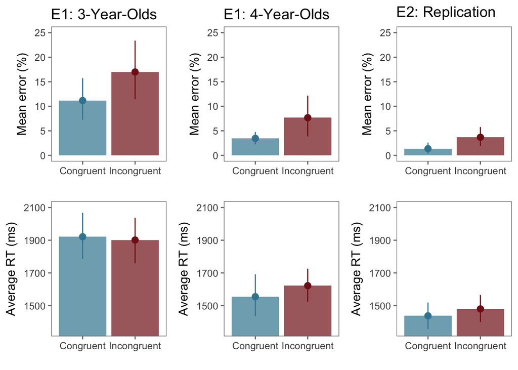

```r
##Make some plots
RTbyCond_3_Plot <- RTData_E1 %>%
  filter(AgeGroup==1) %>%
  group_by (Congruency, Subject) %>%
  summarize(meanRT = mean(RT)) %>%
  group_by (Congruency) %>%
  multi_boot_standard(col = "meanRT")

RTbyCond_4_Plot <- RTData_E1 %>%
  filter(AgeGroup==2) %>%
  group_by (Congruency, Subject) %>%
  summarize(meanRT = mean(RT)) %>%
  group_by (Congruency) %>%
  multi_boot_standard(col = "meanRT")

RTbyCond_E2_Plot <- fastKids_RT %>%
  group_by (Congruency, Subject) %>%
  summarize(meanRT = mean(RT)) %>%
  group_by (Congruency) %>%
  multi_boot_standard(col = "meanRT")

#######
ErrbyCond_3_Plot <- ErrorData_E1 %>%
  filter(AgeGroup==1) %>%
  group_by (Congruency, Subject) %>%
  summarize(meanError = mean(error)) %>%
  mutate(meanError = meanError*100)  %>%
  group_by (Congruency) %>%
  multi_boot_standard(col = "meanError")

ErrbyCond_4_Plot <- ErrorData_E1 %>%
  filter(AgeGroup==2) %>%
  group_by (Congruency, Subject) %>%
  summarize(meanError = mean(error)) %>%
  mutate(meanError = meanError*100)  %>%
  group_by (Congruency) %>%
  multi_boot_standard(col = "meanError")

ErrbyCond_E2_Plot <- allData_E2_errors_raw %>%
  group_by (Congruency, Subject) %>%
  summarize(meanError = mean(error)) %>%
  mutate(meanError = meanError*100)  %>%
  group_by (Congruency) %>%
  multi_boot_standard(col = "meanError")

###
g1=ggplot(RTbyCond_3_Plot, aes(x = Congruency, y = mean, fill=Congruency)) +
  theme_few() +
  geom_bar(stat = "identity", position= "dodge", alpha=.7) +
  scale_fill_manual(values=c("#3C86A0", "#821919")) +
  geom_pointrange(aes(ymin = ci_lower, ymax = ci_upper), color=c("#3C86A0", "#821919")) +
  labs(y = "Average RT (ms)", x ="") +
  theme(legend.position="none") +
  scale_x_discrete(labels=c("Congruent","Incongruent")) +
  scale_y_continuous(limits=c(1350,2100), oob = rescale_none)

g2=ggplot(RTbyCond_4_Plot, aes(x = Congruency, y = mean, fill=Congruency)) +
  theme_few() +
  geom_bar(stat = "identity", position= "dodge", alpha=.7) +
  scale_fill_manual(values=c("#3C86A0", "#821919")) +
  geom_pointrange(aes(ymin = ci_lower, ymax = ci_upper), color=c("#3C86A0", "#821919")) +
  labs(y = "Average RT (ms)", x ="") +
  theme(legend.position="none") +
  scale_x_discrete(labels=c("Congruent","Incongruent")) +
  scale_y_continuous(limits=c(1350,2100), oob = rescale_none)

g3=ggplot(RTbyCond_E2_Plot, aes(x = Congruency, y = mean, fill=Congruency)) +
  theme_few() +
  geom_bar(stat = "identity", position= "dodge", alpha=.7) +
  scale_fill_manual(values=c("#3C86A0", "#821919")) +
  geom_pointrange(aes(ymin = ci_lower, ymax = ci_upper), color=c("#3C86A0", "#821919")) +
  labs(y = "Average RT (ms)", x ="") +
  theme(legend.position="none") +
  scale_x_discrete(labels=c("Congruent","Incongruent")) +
  scale_y_continuous(limits=c(1350,2100), oob = rescale_none)

###
g4=ggplot(ErrbyCond_3_Plot, aes(x = Congruency, y = mean, fill=Congruency)) +
  theme_few() +
 geom_bar(stat = "identity", position= "dodge", alpha=.7) +
  scale_fill_manual(values=c("#3C86A0", "#821919")) +
  geom_pointrange(aes(ymin = ci_lower, ymax = ci_upper), color=c("#3C86A0", "#821919")) +
  labs(y = "Mean error (%)", x ="") +
  theme(legend.position="none") +
  scale_x_discrete(labels=c("Congruent","Incongruent")) +
  ylim(c(0, 25)) +
  ggtitle("E1: 3-Year-Olds")

g5=ggplot(ErrbyCond_4_Plot, aes(x = Congruency, y = mean, fill=Congruency)) +
  theme_few() +
 geom_bar(stat = "identity", position= "dodge", alpha=.7) +
  scale_fill_manual(values=c("#3C86A0", "#821919")) +
  geom_pointrange(aes(ymin = ci_lower, ymax = ci_upper), color=c("#3C86A0", "#821919")) +
  labs(y = "Mean error (%)", x ="") +
  theme(legend.position="none") +
  scale_x_discrete(labels=c("Congruent","Incongruent")) +
  ylim(c(0, 25)) +
  ggtitle("E1: 4-Year-Olds")

g6=ggplot(ErrbyCond_E2_Plot, aes(x = Congruency, y = mean, fill=Congruency)) +
  theme_few() +
 geom_bar(stat = "identity", position= "dodge", alpha=.7) +
  scale_fill_manual(values=c("#3C86A0", "#821919")) +
  geom_pointrange(aes(ymin = ci_lower, ymax = ci_upper), color=c("#3C86A0", "#821919")) +
  labs(y = "Mean error (%)", x ="") +
  theme(legend.position="none") +
  scale_x_discrete(labels=c("Congruent","Incongruent")) +
  ylim(c(0, 25)) +
  ggtitle("E2: Replication")

compiledPlot=ggarrange(g4,g5,g6,g1,g2,g3, nrow=2) # errors first, then RT
```

```r
#compiledPlot=ggarrange(g1,g2,g3,g4,g5,g6, nrow=2)
ggsave("Figure3-E1andE2.pdf", width = 10, height = 6,unit =  "in", plot = compiledPlot, path="./figures/", device = "tiff",dpi = 300)
```

### Supplemental Figure 2

Plot raw data (errors, RT) for each subject in each age group / experiment

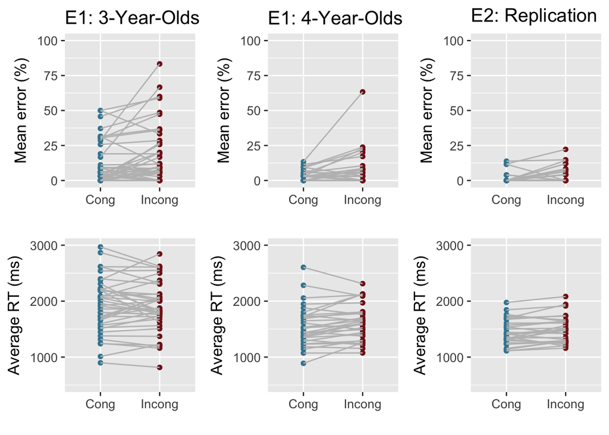

```r
RTbyCond_3_Vals <- RTData_E1 %>%
  filter(AgeGroup==1) %>%
  group_by (Congruency, Subject) %>%
  summarize(meanRT = mean(RT))

RTbyCond_4_Vals <- RTData_E1 %>%
  filter(AgeGroup==2) %>%
  group_by (Congruency, Subject) %>%
  summarize(meanRT = mean(RT))

RTbyCond_E2_Vals <- fastKids_RT %>%
  group_by (Congruency, Subject) %>%
  summarize(meanRT = mean(RT))

#######
ErrbyCond_3_Vals <- ErrorData_E1 %>%
  filter(AgeGroup==1) %>%
  group_by (Congruency, Subject) %>%
  summarize(meanError = mean(error)) %>%
  mutate(meanError = meanError*100)

ErrbyCond_4_Vals <- ErrorData_E1 %>%
  filter(AgeGroup==2) %>%
  group_by (Congruency, Subject) %>%
  summarize(meanError = mean(error)) %>%
  mutate(meanError = meanError*100)

ErrbyCond_E2_Vals <- allData_E2_errors_raw %>%
  group_by (Congruency, Subject) %>%
  summarize(meanError = mean(error)) %>%
  mutate(meanError = meanError*100)
###

font_size_base = 13 ## for html
# font_size_base = 20 ## for rendering in pdf

g1=ggplot(RTbyCond_3_Vals, aes(x = Congruency, y = meanRT)) +
  geom_point(aes(colour=factor(Congruency))) +
  geom_line(aes(group = Subject), color="grey")  +
  theme_grey(base_size = font_size_base) +
  scale_colour_manual(values=c("#3C86A0", "#821919")) +
  labs(y = "Average RT (ms)", x ="") +
  theme(legend.position="none") +
  scale_x_discrete(labels=c("Cong","Incong")) +
  scale_y_continuous(limits=c(500,3000), oob = rescale_none)


g2=ggplot(RTbyCond_4_Vals, aes(x = Congruency, y = meanRT)) +
  geom_point(aes(colour=factor(Congruency))) +
  geom_line(aes(group = Subject), color="grey")  +
  theme_grey(base_size = font_size_base) +
  scale_colour_manual(values=c("#3C86A0", "#821919"))+
  labs(y = "Average RT (ms)", x ="") +
  theme(legend.position="none") +
  scale_x_discrete(labels=c("Cong","Incong")) +
  scale_y_continuous(limits=c(500,3000), oob = rescale_none)


g3=ggplot(RTbyCond_E2_Vals, aes(x = Congruency, y = meanRT)) +
  geom_point(aes(colour=factor(Congruency))) +
  geom_line(aes(group = Subject), color="grey")  +
  theme_grey(base_size = font_size_base) +
  scale_colour_manual(values=c("#3C86A0", "#821919"))+
  labs(y = "Average RT (ms)", x ="") +
  theme(legend.position="none") +
  scale_x_discrete(labels=c("Cong","Incong")) +
  scale_y_continuous(limits=c(1350,2100), oob = rescale_none) +
  labs(y = "Average RT (ms)", x ="") +
  theme(legend.position="none") +
  scale_x_discrete(labels=c("Cong","Incong")) +
  scale_y_continuous(limits=c(500,3000), oob = rescale_none)
###
g4=ggplot(ErrbyCond_3_Vals, aes(x = Congruency, y = meanError)) +
  geom_point(aes(colour=factor(Congruency))) +
  geom_line(aes(group = Subject), color="grey")  +
  theme_grey(base_size = font_size_base) +
  scale_colour_manual(values=c("#3C86A0", "#821919"))+
  labs(y = "Mean error (%)", x ="") +
  theme(legend.position="none") +
  scale_x_discrete(labels=c("Cong","Incong")) +
  ylim(c(0, 100)) +
  ggtitle("E1: 3-Year-Olds")

g5=ggplot(ErrbyCond_4_Vals, aes(x = Congruency, y = meanError)) +
  geom_point(aes(colour=factor(Congruency))) +
  geom_line(aes(group = Subject), color="grey")  +
  theme_grey(base_size = font_size_base) +
  scale_colour_manual(values=c("#3C86A0", "#821919")) +
  labs(y = "Mean error (%)", x ="") +
  theme(legend.position="none") +
  scale_x_discrete(labels=c("Cong","Incong")) +
  ylim(c(0, 100)) +
  ggtitle("E1: 4-Year-Olds")

g6=ggplot(ErrbyCond_E2_Vals, aes(x = Congruency, y = meanError)) +
  geom_point(aes(colour=factor(Congruency))) +
  geom_line(aes(group = Subject), color="grey")  +
  theme_grey(base_size = font_size_base) +
  scale_colour_manual(values=c("#3C86A0", "#821919")) +
  labs(y = "Mean error (%)", x ="") +
  theme(legend.position="none",axis.ticks.x=element_blank()) +
  scale_x_discrete(labels=c("Cong","Incong")) +
  ylim(c(0, 100)) +
  ggtitle("E2: Replication")


compiledPlot=ggarrange(g4,g5,g6,g1,g2,g3, nrow=2) # errors first, then RT
```

```r
ggsave("SuppFigure2-IndivData.tiff", width = 11.5, height = 6,unit =  "in", plot = compiledPlot, path="./figures/", device = "tiff",dpi = 300)
```

# Item-Pair Analyses

## Load and preprocess data

Get Stroop item effects from E1/E2 and adults data; merge

```r
# get Stroop item effects for all 4-year-olds
stroopItemEffects<-RTbyCond_4_Raw %>%
  full_join(fastKids_RT) %>%
  group_by(Item, Congruency) %>%
  summarize(meanRT = mean(RT)) %>%
  group_by(Item) %>%
  summarize(stroopRT = meanRT[Congruency==2] - meanRT[Congruency==1])
# get Stroop item effects for all errors
stroopItemEffects_Errors <- ErrorData_E1 %>%
  mutate(Subject = as.factor(Subject)) %>%
  filter(AgeGroup==2) %>% ## only get 4-year-olds
  full_join(allData_E2_errors_raw) %>%
  group_by (Item, Congruency) %>%
  summarize(meanError = mean(error)) %>%
  mutate(meanError = meanError*100)  %>%
  group_by(Item) %>%
  summarize(stroopError = meanError[Congruency==2] - meanError[Congruency==1])
## import adult data
adultStroopItemEffects=read.csv("data/AdultItemEffects.csv") %>%
  mutate(Item = as.factor(Item))

## merge adult and children's data
stroopItemEffects <- stroopItemEffects %>%
  mutate(childStroopRT = stroopRT) %>%
  full_join(adultStroopItemEffects)
```

## Adult-Kid correlations

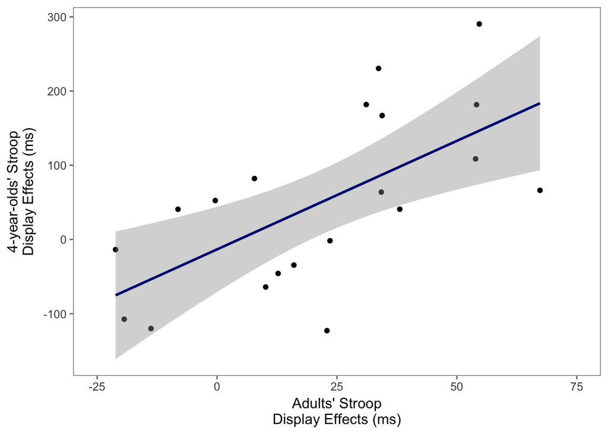

```r
# correlate item effects
adultKidCorr=cor.test(stroopItemEffects$childStroopRT,stroopItemEffects$AdultStroopRT)

# make plot
ggplot(stroopItemEffects, aes(x = AdultStroopRT, y = childStroopRT)) +
  theme_few() +
  geom_point()  +
  geom_smooth(method="lm", color="navy") +
  #draws x and y axis line
  # theme(axis.line = element_line(color = 'black')) +
  labs(x="Adults' Stroop\nDisplay Effects (ms)", y="4-year-olds' Stroop\nDisplay Effects (ms)")+
xlim(c(-25, 75))
```

```r
ggsave("Figure4-AdultKidCorr.tiff", width = 4, height = 4,unit =  "in", plot = last_plot(), path="./figures/", device = "tiff",dpi = 300)
```

We found that item effects for preschoolers and adults were highly correlated (r = 0.64, p = 0; Figure 4); the same pairs of objects generated stronger Stroop item effects in both adults and children.

## Load familiarity ratings and get basic descriptives

```r
## import fam data
famRatings=read.csv("data/FamiliarityRatings_4YearOlds_CSV.csv")

famRatingsSummary <- famRatings %>%
  mutate(Subject = as.factor(Subject)) %>%
  group_by(Subject) %>%
  summarize(meanBasic = mean(CorrectBasic)*100, meanSize = mean(CorrectSize)*100, meanIncorrect = mean(RespondedButIncorrect)*100)
##
noResponses = mean(100 - (famRatingsSummary$meanBasic+famRatingsSummary$meanIncorrect))
```

Overall, children identified the correct basic-level category of the objects 76.1% of the time, gave an incorrect answer 16.8% of the time, and did not give a response 7.08% of the time. Some items were always identified correctly (i.e., apple, 100% identification rate), while others were rarely identified correctly (i.e., perfume bottle, 33.3% identification rate).

### Assess reliability of familiarity ratings

```r
## function to divide data based on # of subjects and subject indexes
divideData <- function(numSubs,subIndexes){
  shuffled_subs=sample(numSubs,numSubs,replace=FALSE)
  g1 = shuffled_subs[1:(numSubs/2)]
  g2 = shuffled_subs[((numSubs/2)+1):numSubs]
  s1 = subIndexes[g1]
  s2 = subIndexes[g2]
  return(data.frame(s1,s2))
}

numSubs = length(unique(famRatings$Subject))
subIndexes = unique(famRatings$Subject)
reliability_basic_level=numeric(length=100) # open up variable for 100 iterations
reliability_size=numeric(length=100)

## for each iteration
for (i in c(1:100)){
  ## get two random samples
  random_subjects=divideData(numSubs,subIndexes)

  sample_1 <- famRatings %>%
    filter(Subject %in% random_subjects$s1) %>%
    group_by(ImageFileName, ImPairNumber) %>%
    summarize(meanBasic = mean(CorrectBasic))

  sample_2 <- famRatings %>%
    filter(Subject %in% random_subjects$s2) %>%
    group_by(ImageFileName, ImPairNumber) %>%
    summarize(meanBasic = mean(CorrectBasic))

  out=cor.test(sample_1$meanBasic,sample_2$meanBasic) ## correlate avg basic-level recognizability across two sets of 12
  reliability_basic_level[i]=out$estimate # save it
}

for (i in c(1:100)){
  ## get two random samples
  random_subjects=divideData(numSubs,subIndexes)

  sample_1 <- famRatings %>%
    filter(Subject %in% random_subjects$s1) %>%
    group_by(ImageFileName, ImPairNumber) %>%
    summarize(meanSize = mean(CorrectSize))

  sample_2 <- famRatings %>%
    filter(Subject %in% random_subjects$s2) %>%
    group_by(ImageFileName, ImPairNumber) %>%
    summarize(meanSize = mean(CorrectSize))

  out=cor.test(sample_1$meanSize,sample_2$meanSize) ## correlate avg basic-level recognizability across two sets of 12
  reliability_size[i]=out$estimate # save it
}
```

To assess the reliability of the ratings, we re-computed how correctly each item was identified in 100 random split halves of our 24 participants and correlated the identification rates in each split half; on average, children were relatively reliable across this set of 40 items, with an average split-half correlation of r=0.87, SD=0.03.

### Descriptive plots by each item

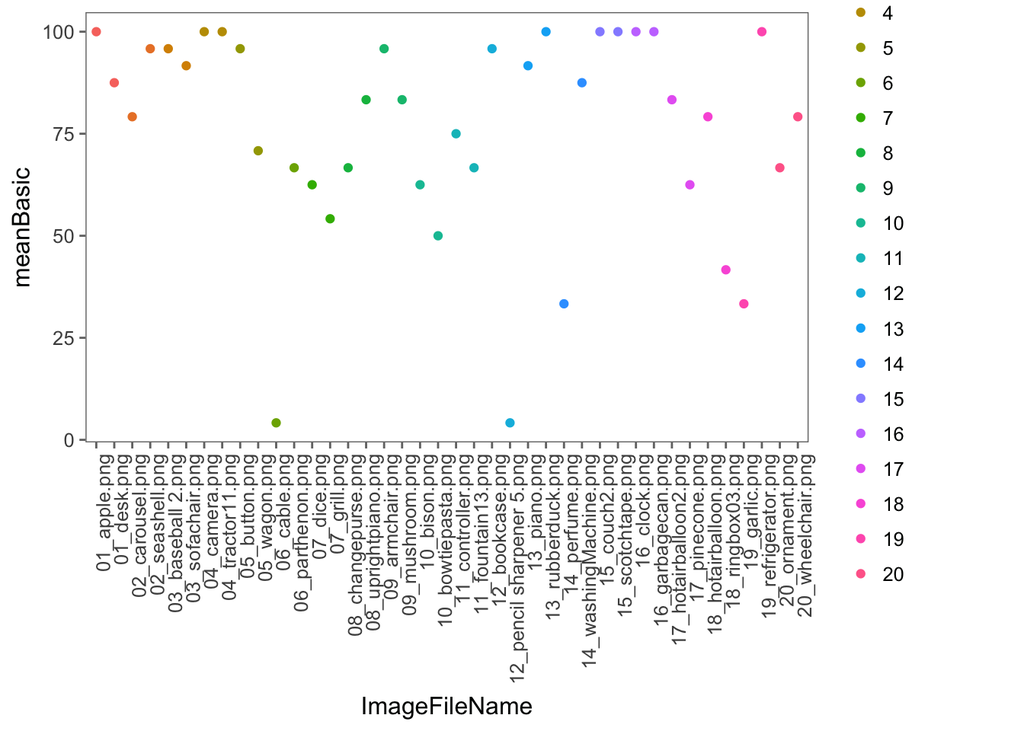

```r
famRatingsByItem <- famRatings %>%
  mutate(ImPairNumber = as.factor(ImPairNumber)) %>%
  group_by(ImageFileName, ImPairNumber) %>%
  summarize(meanBasic = mean(CorrectBasic)*100, meanSize = mean(CorrectSize)*100, meanIncorrect = mean(RespondedButIncorrect)*100)

### Visualize basic-level ID by item
ggplot(famRatingsByItem, aes(x = ImageFileName, y = meanBasic,col=ImPairNumber)) +
  geom_point()  +
  theme_few() +
  theme(axis.text.x = element_text(angle = 90, hjust = 1))
```

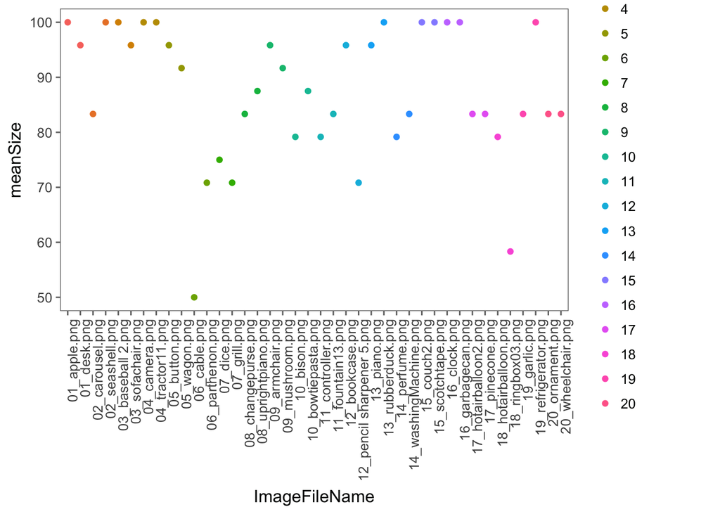

```r
ggplot(famRatingsByItem, aes(x = ImageFileName, y = meanSize, col=ImPairNumber)) +
  geom_point()  +
  theme_few() +
  theme(axis.text.x = element_text(angle = 90, hjust = 1))
```

```r
##
bbq <- famRatingsByItem %>%
  filter(ImageFileName == "07_grill.png")

die <- famRatingsByItem %>%
  filter(ImageFileName == "07_dice.png")

desk <- famRatingsByItem %>%
  filter(ImageFileName == "01_desk.png")

apple <- famRatingsByItem %>%
  filter(ImageFileName == "01_apple.png")
```

### How well did children identify the basic-level identities?

```r
## Get imPairs (Stroop Displays) where basic-level ID is above 75%
highBasic <- famRatings %>%
  group_by(ImageFileName,ImPairNumber) %>%
  summarize(meanBasic = mean(CorrectBasic)) %>%
  mutate(highBasic = meanBasic > .75) %>%
  group_by(ImPairNumber) %>%
  summarize(countHighBasic = sum(highBasic))
```

### Separate items based on basic-level ID for further analysis

```r
## Output basic-level identification on these sets of "well" vs "poorly" identified displays
highBasicDisplays=highBasic$ImPairNumber[highBasic$countHighBasic==2] ## 2 -- both items should be "true", i.e., greater than 75% threshold
famRatingsHighBasic <- famRatingsByItem %>%
  filter(is.element(ImPairNumber,highBasicDisplays))
##
lowBasicDisplays=highBasic$ImPairNumber[highBasic$countHighBasic<2]
famRatingsLowBasic <- famRatingsByItem %>%
  filter(is.element(ImPairNumber,lowBasicDisplays))

## pairs where both items were poorly identified
BothPoorlyIdentified=highBasic$ImPairNumber[highBasic$countHighBasic==0]
```

### Basic-level ID paragraph

We then grouped together pairs where the basic-level identities of both the big and small objects were well identified (greater than 75%, 8/20 pairs, M = 95.05 % across all 16 items) and pairs where one or more items were poorly identified (75% or less; 12/20 pairs, M = 63.54% across all 24 items). Most pairs contained only one item that was poorly identified (8/12 pairs) and four pairs contained two items that were both poorly identified. See Figure 5A for an example of a pair of objects where both items were poorly identified by 4-year-olds (the barbeque, 54.17% identification rate, the die, 62.5% identification rate) and a pair where both items were well identified by 4-year-olds (the desk, 87.5% identification rate; the apple, 100% identification rate).

## Are there difference in Size-Stroop effects according to identification?

### …for reaction times

```r
stroopItemEffectsHighID <- stroopItemEffects %>%
  mutate(ImPairNumber = as.factor(Item)) %>%
  filter(is.element(ImPairNumber, highBasicDisplays))

stroopItemEffectsLowID <- stroopItemEffects %>%
  mutate(ImPairNumber = as.factor(Item)) %>%
  filter(is.element(ImPairNumber, lowBasicDisplays))

### output
mean(stroopItemEffectsHighID$childStroopRT)
```

```
## [1] -4.37242
```

```r
mean(stroopItemEffectsLowID$childStroopRT)
```

```
## [1] 85.96964
```

```r
highvLowBasic=t.test(stroopItemEffectsHighID$childStroopRT,stroopItemEffectsLowID$childStroopRT, var.equal = TRUE)

## imPair 7 - grill/desk
unique(famRatings$ImageFileName[famRatings$ImPairNumber==7])
```

```
## [1] 07_grill.png 07_dice.png
## 40 Levels: 01_apple.png 01_desk.png 02_carousel.png ... 20_wheelchair.png
```

```r
bbqDie=stroopItemEffects$childStroopRT[stroopItemEffects$Item==7]

# imPair 1 - apple/desk
unique(famRatings$ImageFileName[famRatings$ImPairNumber==1])
```

```
## [1] 01_apple.png 01_desk.png
## 40 Levels: 01_apple.png 01_desk.png 02_carousel.png ... 20_wheelchair.png
```

```r
appleDesk=stroopItemEffects$childStroopRT[stroopItemEffects$Item==1]
```

If anything, pairs of objects that were well-identified at the basic level generated smaller Size-Stroop effects in RTs (M = -4.37ms) than pairs of objects that were not both well-identified (M = 85.97ms; unpaired two-sample t-test, (t(18)=-1.77, p = 0.09); Figure 5B). For example, the Size-Stroop RT effect for the poorly recognized barbecue/die pair was 66.24ms , whereas the Size-Stroop RT effect for the well-recognized desk/apple pair was -119.99ms (Figure 5A).

### …for error rates?

```r
stroopItemEffectsHighID_Errors <- stroopItemEffects_Errors %>%
  mutate(ImPairNumber = as.factor(Item)) %>%
  filter(is.element(ImPairNumber, highBasicDisplays))

stroopItemEffectsLowID_Errors <- stroopItemEffects_Errors %>%
  mutate(ImPairNumber = as.factor(Item)) %>%
  filter(is.element(ImPairNumber, lowBasicDisplays))

### output
mean(stroopItemEffectsHighID_Errors$stroopError)
```

```
## [1] 2.716674
```

```r
mean(stroopItemEffectsLowID_Errors$stroopError)
```

```
## [1] 3.27785
```

```r
highvLowBasic_Errors=t.test(stroopItemEffectsHighID_Errors$stroopError,stroopItemEffectsLowID_Errors$stroopError, var.equal = TRUE)
```

### How well did children identify the size of the objects?

```r
famRatingsBySub_Misidentifications<- famRatings %>%
  filter(RespondedButIncorrect==1) %>%
  group_by(Subject) %>%
  summarize(meanSize = mean(CorrectSize)*100)

misIDvChance=t.test(famRatingsBySub_Misidentifications$meanSize, mu=.5)
```

### Size identification paragraph

In a second analysis, we counted as correct any identification of the target as an object in the same real-world size category, as most often, children’s misidentifications were of objects from the same real-world size category as the target (though rarely from the same taxonomic superordinate category; 75.1% of misidentifications, t-test against 50%, t(23) = 16.36, p = 0.

### Separate items by a median split on size identification for further analysis

```r
highSize <- famRatings %>%
  group_by(ImageFileName,ImPairNumber) %>%
  summarize(meanSize = mean(CorrectSize))
# get median of size identification
medianSize = median(highSize$meanSize)
#
highSize <- highSize %>%
  mutate(highSize = meanSize >= medianSize) %>%
  group_by(ImPairNumber) %>%
  summarize(countHighSize= sum(highSize))

## Output size identification on these sets of "well" vs "poorly" size identified displays
highSizeDisplays=highSize$ImPairNumber[highSize$countHighSize==2] ## 2 -- both items should be "true", i.e., greater than 75% threshold
famRatingsHighSize <- famRatingsByItem %>%
  filter(is.element(ImPairNumber,highSizeDisplays))
##
lowSizeDisplays=highSize$ImPairNumber[highSize$countHighSize<2]
famRatingsLowSize <- famRatingsByItem %>%
  filter(is.element(ImPairNumber,lowSizeDisplays))
```

Here, we separated pairs where children identified any object within the correct size-category at a rate above the median across all items, as size-identification was relatively high (both items >0.88 correct, 8/20 pairs, M = M = 97.66% across items) and pairs where children identified either object within the correct size-category at a rate below the median (one or both items <0.88% correct, 12/20 pairs, M=80.56% across items).

## Are there difference in Size-Stroop effects according to size identification?

### …for reaction times?

```r
stroopItemEffectsHighSize <- stroopItemEffects %>%
  mutate(ImPairNumber = as.factor(Item)) %>%
  filter(is.element(ImPairNumber, highSizeDisplays))

stroopItemEffectsLowSize <- stroopItemEffects %>%
  mutate(ImPairNumber = as.factor(Item)) %>%
  filter(is.element(ImPairNumber, lowSizeDisplays))

### output
mean(stroopItemEffectsHighSize$childStroopRT)
```

```
## [1] 5.309613
```

```r
mean(stroopItemEffectsLowSize$childStroopRT)
```

```
## [1] 79.51496
```

```r
highvLowSize=t.test(stroopItemEffectsLowSize$childStroopRT,stroopItemEffectsHighSize$childStroopRT, var.equal = TRUE)
```

### …for error rates?

```r
stroopItemEffectsHighSize_Errors <- stroopItemEffects_Errors %>%
  mutate(ImPairNumber = as.factor(Item)) %>%
  filter(is.element(ImPairNumber, highSizeDisplays))

stroopItemEffectsLowSize_Errors <- stroopItemEffects_Errors %>%
  mutate(ImPairNumber = as.factor(Item)) %>%
  filter(is.element(ImPairNumber, lowSizeDisplays))

### output
mean(stroopItemEffectsHighSize_Errors$stroopError)
```

```
## [1] 1.789949
```

```r
mean(stroopItemEffectsLowSize_Errors$stroopError)
```

```
## [1] 3.895667
```

```r
highvLowSize_Error=t.test(stroopItemEffectsLowSize_Errors$stroopError,stroopItemEffectsHighSize_Errors$stroopError, var.equal = TRUE)
```

## Replot adult-kid correlations as a function of basic-level identification scores.

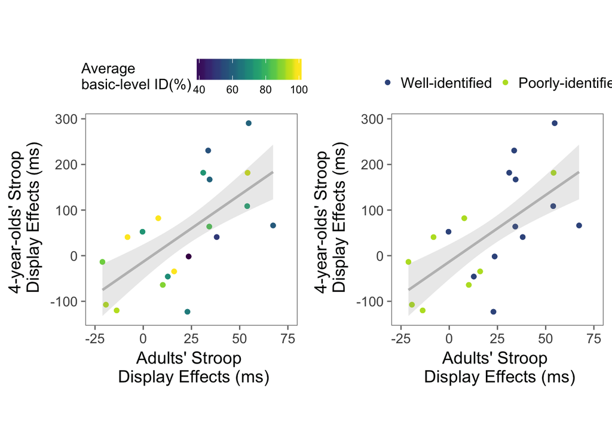

```r
## plot it!
stroopByID <- famRatingsByItem %>%
  group_by(ImPairNumber) %>%
  mutate(meanBasicPair = mean(meanBasic), meanSizePair = mean(meanSize) ) %>%
  mutate(Item = as.factor(ImPairNumber)) %>%
  mutate(highBasicID=is.element(Item, highBasicDisplays)) %>%
  left_join(stroopItemEffects)
plot1=ggplot(stroopByID, aes(x = AdultStroopRT, y = childStroopRT, col=meanBasicPair)) +
  geom_point() +
  scale_color_viridis(option="D",name="Average\nbasic-level ID(%)") +
  theme_few(base_size=14) +
  geom_smooth(method="lm", color="grey", alpha=.2) +
  theme(legend.position = "top") +
  labs(x="Adults' Stroop \n Display Effects (ms)", y="4-year-olds' Stroop \n Display Effects (ms)")+
   xlim(c(-25, 75))  +
   theme(aspect.ratio=1) + theme(
    legend.text = element_text(size = 9),
    legend.title = element_text(size = 12),
    legend.key = element_rect(fill = NA),
    legend.background = element_rect(fill = NA))

plot2=ggplot(stroopByID, aes(x = AdultStroopRT, y = childStroopRT, col=highBasicID)) +
  geom_point() +
  theme_few(base_size=14) +
  scale_color_manual(values=c("#39568CFF", "#B8DE29FF"), label = c("Well-identified", "Poorly-identified")) +
  geom_smooth(method="lm", color="grey", alpha=.2) +
  theme(legend.position = "top",aspect.ratio=1) +
  theme(
    legend.text = element_text(size = 12),
    legend.title = element_text(size = 0),
    legend.key = element_rect(fill = NA),
    legend.background = element_rect(fill = NA)) +
  labs(x="Adults' Stroop \n Display Effects (ms)", y="4-year-olds' Stroop \n Display Effects (ms)")+
xlim(c(-25, 75))

E3=ggarrange(plot1,plot2,nrow=1)
```

```r
ggsave("SuppFigure5-AdultvsKids-byFamiliarity.tiff", width = 11.5, height = 5,unit =  "in", plot = E3, path="./figures/", device = "png",dpi = 300)
```